# Theory-driven meta-analysis TRACE

Milou Sep

4/27/2021

# Analysis script for TRACE analyses (based on analyses script Valeria (meta behavior))

Code largely based on // adapted from Bonapersona, V. (2019, May 20). The behavioral phenotype of early life adversity: a 3-level meta-analysis of rodent studies. Retrieved from osf.io/ra947

## Import dataset

(processed with merge_datasets.rmd, recode_merged_data.rmd, add_effect_size_QA.rmd)

```r
data<-readRDS("processed_data/TRACEprepared.RData")
```

In check_comparison.rmd script frequency of observations in groups checked

## Split clinical and preclinical data

- Clinical and preclinical data are analyzed as two separate datasets
- comparison “B” is excluded from clinical data as it does not contain PTSD-patients

[A= non-exposed vs trauma-exposed PTSD (human); B=non-exposed vs trauma exposed no PTSD (human); C=trauma-exposed (noPTSD) vs trauma-exposed PTSD (human); D=non-exposed vs trauma-exposed (no PTSD checked) (animal); E=non-exposed vs trauma-exposed PTSD (animal); F=trauma-exposed (no ptsd) vs trauma-exposed PTSD (animal)]

```r
# Clinical data
data %>%
  filter(subject.cat =="Human") %>%
  filter(comparison !="B") %>%
  droplevels() ->clinical

# Preclinical data
data %>%
  filter(subject.cat =="Animal") %>%
  droplevels() ->preclinical
```

## Remove subgroups with < 4 papers from analyses (by removal of data)

### Clinical

```r
clinical %>% group_by(phase, valence) %>%
  summarize(papers=length(unique(PMID)), comparisons=length(each)) %>% data.frame()
```

```
##   phase valence papers comparisons
## 1     E       F     13          81
## 2     L       F     21          82
## 3     L       N     39          95
## 4     L       T      1           1
## 5     M       E     15          49
## 6     M       F      1           2
## 7     M       N     63         240
## 8     M       T      2           3
```

```r
clinical %>% group_by(phase, valence) %>%
  summarize(papers=length(unique(PMID)), comparisons=length(each)) %>%
  filter(papers <4) %>%
  mutate(
    phase.valence.code = paste(phase, valence,sep=".")
  ) ->excluded.levels.human
excluded.levels.human
```

```
## # A tibble: 3 x 5
## # Groups:   phase [2]
##   phase valence papers comparisons phase.valence.code
##   <fct> <fct>    <int>       <int> <chr>
## 1 L     T            1           1 L.T
## 2 M     F            1           2 M.F
## 3 M     T            2           3 M.T
```

```r
clinical %>%
  mutate(phase.valence.code = paste(phase, valence,sep=".")) ->clinical1
clinical1 %>%
  filter(!(phase.valence.code %in% excluded.levels.human$phase.valence.code)) %>% droplevels() -> clinical.filtered
```

```r
# for checking (should be total numbers of papers above, so here 4)
clinical1 %>% filter((phase.valence.code %in% excluded.levels.human$phase.valence.code)) %>% distinct(PMID)
```

```
##       PMID
## 1 10066999
## 2  1741732
## 3 16714037
## 4 16901721
```

### Preclinical

```r
preclinical %>% group_by(phase, valence) %>%
  summarize(papers=length(unique(PMID)), comparisons=length(each))
```

```
## # A tibble: 7 x 4
## # Groups:   phase [3]
##   phase valence papers comparisons
##   <fct> <fct>    <int>       <int>
## 1 E     F           45         271
## 2 E     T            8          70
## 3 L     F           32          85
## 4 L     N           27         136
## 5 M     F           68         144
## 6 M     N           45          98
## 7 M     T           76         285
```

```r
preclinical %>% group_by(phase, valence) %>%
  summarize(papers=length(unique(PMID)), comparisons=length(each)) %>%
  filter(papers <4) %>%
  mutate(
    phase.valence.code = paste(phase, valence,sep=".")
  ) ->excluded.levels.animal
excluded.levels.animal
```

```
## # A tibble: 0 x 5
## # Groups:   phase [0]
## # … with 5 variables: phase <fct>, valence <fct>, papers <int>,
## #   comparisons <int>, phase.valence.code <chr>
```

> no exclusions needed in preclinial data (levels >=4 papers)

# multilevel models

## Research Question 1: Learning and Memory of stressful and non-stressful information in PTSD patients

### Model - unfilterd data

```r
mod.clinical.total <- rma.mv(yi, vi,
                             random = list(~1 | new.idPTSD , ~1 | PMID),  # valeria had each.. ik heb in oic meta PMID.. results ong same maar beetje anders -> volgens mij is PMID de bedoeling
                             # random = list(~1 | PMID , ~1 | new.idPTSD),  # just for checking -> es expacted exactly the same estimaes
                             # random = ~ 1 | new.idPTSD / each,  # identical results as row above  # https://bookdown.org/MathiasHarrer/Doing_Meta_Analysis_in_R/fitting-a-three-level-model.html
                             # mods   = ~phase.valence - 1,
                             # mods = ~Valence_Grouped:phase-1, # all impaired  (NB E, F and T were grouped as emotional)
                             mods = ~valence:phase-1, # fear ext and fear memory impoved (trauma m NS), rest impaired
                             method = "REML",
                             slab = clinical$reference,  # from old codes milou (change for author/year)
                             data = clinical) # Similar effects with dat2 (trauma learning excluded)
summary(mod.clinical.total)
```

```
##
## Multivariate Meta-Analysis Model (k = 553; method: REML)
##
##     logLik    Deviance         AIC         BIC        AICc
## -2150.6723   4301.3446   4321.3446   4364.3525   4321.7566
##
## Variance Components:
##
##             estim    sqrt  nlvls  fixed      factor
## sigma^2.1  0.0489  0.2210     97     no  new.idPTSD
## sigma^2.2  0.4314  0.6568     92     no        PMID
##
## Test for Residual Heterogeneity:
## QE(df = 545) = 7269.9801, p-val < .0001
##
## Test of Moderators (coefficients 1:8):
## QM(df = 8) = 189.0515, p-val < .0001
##
## Model Results:
##
##                  estimate      se     zval    pval    ci.lb    ci.ub
## valenceF:phaseE   -0.8044  0.1582  -5.0837  <.0001  -1.1145  -0.4943  ***
## valenceF:phaseL   -0.2001  0.1546  -1.2940  0.1957  -0.5032   0.1030
## valenceN:phaseL   -0.6675  0.0916  -7.2867  <.0001  -0.8470  -0.4879  ***
## valenceT:phaseL   -1.2781  0.2955  -4.3255  <.0001  -1.8572  -0.6990  ***
## valenceE:phaseM   -0.6531  0.1129  -5.7822  <.0001  -0.8745  -0.4317  ***
## valenceF:phaseM    0.4249  0.3709   1.1455  0.2520  -0.3021   1.1518
## valenceN:phaseM   -0.5443  0.0872  -6.2399  <.0001  -0.7153  -0.3733  ***
## valenceT:phaseM    0.3571  0.2552   1.3994  0.1617  -0.1431   0.8574
##
## ---
## Signif. codes:  0 '***' 0.001 '**' 0.01 '*' 0.05 '.' 0.1 ' ' 1
```

### Model - filtered data

```r
mod.clinical <- rma.mv(yi, vi,
                       random = list(~1 | new.idPTSD , ~1 | PMID),  # valeria had each.. ik heb in oic meta PMID.. results ong same maar beetje anders -> volgens mij is PMID de bedoeling
                       # random = ~ 1 | new.idPTSD / each,  # identical results as row above  # https://bookdown.org/MathiasHarrer/Doing_Meta_Analysis_in_R/fitting-a-three-level-model.html
                       # mods   = ~phase.valence - 1,
                       # mods = ~Valence_Grouped:phase-1, # all impaired  (NB E, F and T were grouped as emotional)
                       mods = ~valence:phase-1, # fear ext and fear memory impoved (trauma m NS), rest impaired
                       method = "REML",
                       slab = clinical.filtered$reference,  # from old codes milou (change for author/year)
                       data = clinical.filtered) # Similar effects with dat2 (trauma learning excluded)
summary(mod.clinical)
```

```
##
## Multivariate Meta-Analysis Model (k = 547; method: REML)
##
##     logLik    Deviance         AIC         BIC        AICc
## -2137.5010   4275.0020   4289.0020   4319.0689   4289.2118
##
## Variance Components:
##
##             estim    sqrt  nlvls  fixed      factor
## sigma^2.1  0.0489  0.2210     97     no  new.idPTSD
## sigma^2.2  0.4310  0.6565     92     no        PMID
##
## Test for Residual Heterogeneity:
## QE(df = 542) = 7241.9996, p-val < .0001
##
## Test of Moderators (coefficients 1:5):
## QM(df = 5) = 163.5333, p-val < .0001
##
## Model Results:
##
##                  estimate      se     zval    pval    ci.lb    ci.ub
## valenceF:phaseE   -0.8044  0.1582  -5.0857  <.0001  -1.1144  -0.4944  ***
## valenceF:phaseL   -0.2001  0.1546  -1.2946  0.1955  -0.5031   0.1029
## valenceN:phaseL   -0.6672  0.0916  -7.2866  <.0001  -0.8467  -0.4878  ***
## valenceE:phaseM   -0.6552  0.1129  -5.8013  <.0001  -0.8766  -0.4339  ***
## valenceN:phaseM   -0.5440  0.0872  -6.2392  <.0001  -0.7149  -0.3731  ***
##
## ---
## Signif. codes:  0 '***' 0.001 '**' 0.01 '*' 0.05 '.' 0.1 ' ' 1
```

### add contrasts

```r
TRACE_clinical_valence_phase <- function(model){

  # some info: Test linear combinations (http://www.metafor-project.org/doku.php/tips:testing_factors_lincoms)
  # http://www.metafor-project.org/doku.php/tips:multiple_factors_interactions

 extinction <- anova(model, L = c(1,0, 0, 0,0))
  fearLearning <- anova(model, L = c(0,1, 0, 0,0))
  neutralLearning <- anova(model, L = c(0,0, 1, 0,0))
  emotionalMemory <- anova(model, L = c(0,0, 0, 1,0))
  neutralMemory <- anova(model, L = c(0,0, 0, 0, 1))


  # Posthoc RQ2 influence of valence on learning or memory
  valence.learning <-anova(model, L = c(0, 1, -1, 0,0)) # neutral = -
  valence.memory <- anova(model, L = c(0,0,0, 1, -1))


  ##Summary results organized in table
  resultMain <- data.frame(matrix(data = NA, nrow = 7, ncol = 8)) #V new

  colnames(resultMain) <- c("test", "effectsize", "se", "ci.lb", "ci.ub", "Zvalue", "Pvalue", "Pvalue_bonfCorr")

  resultMain[,1] <- c( "neutral Learning", "neutral Memory", "fear Learning", "emotional Memory", "fear Extinction",
    "valence.learning: neutral vs emotional (learning)", "valence.memory: neutral vs emotional (memory)")

  resultMain[,2] <- round(c(
    neutralLearning$Lb, neutralMemory$Lb,
    fearLearning$Lb, emotionalMemory$Lb,
    extinction$Lb,
        valence.learning$Lb, valence.memory$Lb
  ), digits = 4) #effect size

  resultMain[,3] <- round(c( neutralLearning$se, neutralMemory$se,
    fearLearning$se, emotionalMemory$se,
    extinction$se,
      valence.learning$se, valence.memory$se
  ), digits = 4) #se

  resultMain[,4] <- round(resultMain[,2] - (resultMain[,3] * 1.96), digits = 4) #CI lower
  resultMain[,5] <- round(resultMain[,2] + (resultMain[,3] * 1.96), digits = 4) #CI upper

  resultMain[,6] <- round(c(
    neutralLearning$zval, neutralMemory$zval,
    fearLearning$zval, emotionalMemory$zval,
    extinction$zval,
 valence.learning$zval, valence.memory$zval
  ), digits = 4)  #zvalues

  resultMain[,7] <- round(c(
    neutralLearning$pval, neutralMemory$pval,
    fearLearning$pval, emotionalMemory$pval,
    extinction$pval,
valence.learning$pval, valence.memory$pval
  ), digits = 4)  #pvalues

  resultMain[,8] <- round(p.adjust(resultMain[,7], method = "bonferroni", n = 7), digits = 4) #pvalue bonf correction

  return(resultMain)

}

TRACE_clinical_valence_phase(mod.clinical)->clinical.results
```

### create plot

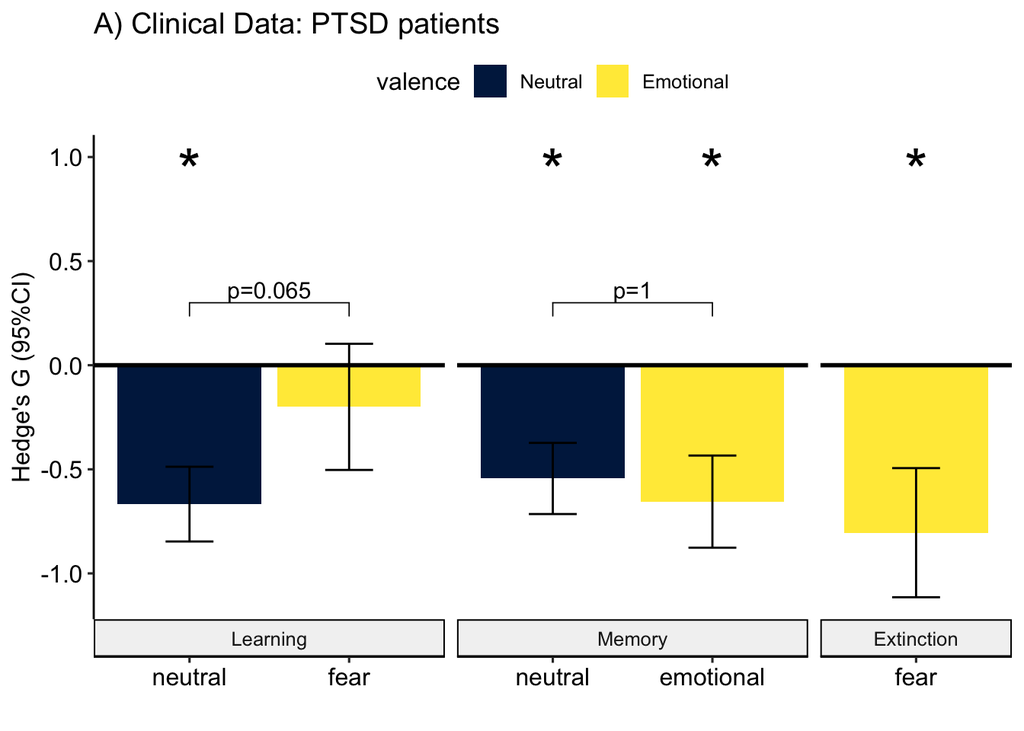

```r
clinical.results %>%
  filter(test %in% c( "neutral Learning", "neutral Memory", "fear Learning", "emotional Memory", "fear Extinction")) %>%
  mutate(
    valence = ifelse(test %in% c("neutral Learning", "neutral Memory"), "Neutral", "Emotional"),
    phase = case_when(
      test %in% c( "neutral Learning", "fear Learning") ~ "Learning",
      test %in% c( "neutral Memory", "emotional Memory") ~ "Memory",
      test == "fear Extinction" ~ "Extinction"
    ),
    # phase = factor(phase, levels = c("Learning", "Memory", "Extinction"))  # dan error with plot

    # signal sig. categories. Add index for p-values smaller than 0.05
    sig =ifelse(Pvalue_bonfCorr<0.05, 1, 0),

    valence= factor(valence, levels =c("Neutral", "Emotional")),
    # plot_data_coded$test = factor(plot_data_coded$test)
    test = factor(test, levels = c("neutral Learning", "fear Learning", "neutral Memory", "emotional Memory", "fear Extinction")#,
                  # labels = c("neutral", "fear", "neutral", "emotional", "fear")
    )
  ) ->clinical_plot_data_coded


# plot_data_coded$sig<- ifelse(plot_data_coded$Pvalue_bonfCorr  <0.05, 1, 0)


# https://www.datanovia.com/en/blog/ggpubr-how-to-add-p-values-generated-elsewhere-to-a-ggplot/

clinical.results %>%
  select(test,p=Pvalue_bonfCorr) %>%
  filter(grepl("valence",test,fixed = T)) %>%
  mutate(
    group1 = case_when(
      # grepl("phase.neutral",test) ~ "neutral Learning",
      #   grepl("phase.emotional",test) ~ "fear Learning"#,

      grepl("valence.learning",test) ~ "neutral Learning",
      grepl("valence.memory",test) ~ "neutral Memory"
    ),

    group2 = case_when(
      # grepl("phase.neutral",test) ~ "neutral Memory",
      # grepl("phase.emotional",test) ~ "emotional Memory"#,

      grepl("valence.learning",test) ~ "fear Learning",
      grepl("valence.memory",test) ~ "emotional Memory"
    ),

    phase =
      case_when(
        grepl("learning",test) ~ "Learning",
        grepl("memory",test) ~ "Memory"),
    # c( "Learning", "Memory"),
    p.adj = ifelse(p == 0, yes = "p<.001", no = paste0("p=",round(p,3)))
    # valence = c("Neutral", "Emotional", NA, NA)
  ) %>% group_by(phase)-> clinical.posthoc.valence


# plot_data_coded$valence= factor(plot_data_coded$valence, levels =c("Neutral", "Emotional"))
# # plot_data_coded$test = factor(plot_data_coded$test)
# plot_data_coded$test = factor(plot_data_coded$test, levels = c("neutral Learning", "fear Learning", "neutral Memory", "emotional Memory", "fear Extinction")#,
#                               # labels = c("neutral", "fear", "neutral", "emotional", "fear")
# )


PLOT.clinical <-
  ggplot(clinical_plot_data_coded,
         aes(x = test, y = effectsize, fill=valence)) +
  labs(
     title = "A) Clinical Data: PTSD patients",
    # subtitle = "PTSD patients",
    y="Hedge's G (95%CI)", # could also be "Standardized mean difference"
    x="") +
  facet_grid (.~ factor(phase, levels =c("Learning", "Memory", "Extinction")),  # width scaled (better for extinction)
              scales = "free_x", space = "free_x", switch = "x" # labels onder
              # je kan de andere factor levels nog toevoegen en dan hier drop =F, bv voor het vergelijkbaar maken met dieren?
  ) +
  # theme_linedraw() +
   theme_pubr(base_size = 12)+

  # theme(plot.title = element_text(hjust = 0.5)) +
  # theme(plot.subtitle = element_text(hjust = 0.5, face="italic")) +
  # scale_fill_manual(
  #   values= c( "Neutral" = "steelblue2", # Colours: http://sape.inf.usi.ch/quick-reference/ggplot2/colour
  #              "Emotional" = "tomato2")) +

       scale_fill_viridis(discrete = TRUE, #begin = 0.1, end = 0.9 ,
                          option = "cividis") +


  geom_bar(stat = "identity")+
  geom_hline(yintercept = 0, size = 1) +
  geom_errorbar(aes(ymin = ci.lb,
                    ymax = ci.ub),
                width = .3) +
  # theme(axis.text.x = element_text(angle = 45, vjust = 1, hjust=1)) +

  # sig marks
  geom_point(data = clinical_plot_data_coded[clinical_plot_data_coded$sig ==1, ],aes(x=test, y=1), shape = "*", size=10, show.legend = FALSE) +  # to make position dynamic use: y=ci.ub+1.5

  # y_sig_position <- 1 #  ifelse(title=='Clinical Data', 1  , 3.3 )
  #  title='Preclinical Data'

  ggpubr::stat_pvalue_manual( data.frame(clinical.posthoc.valence), inherit.aes=F,
                              y.position = 0.3,
                              # label = "p = {round(p,3)}",
                              label =  "p.adj",

                              size=4) +

  scale_x_discrete(labels=c("neutral Learning" = "neutral",
                            "fear Learning" = "fear",
                            "neutral Memory" = "neutral",
                            "emotional Memory" = "emotional",
                            "fear Extinction" = "fear"))

PLOT.clinical
```

### save data table

save

```r
clinical.results[,2:8]<-round(clinical.results[,2:8],3)
# correct pvalue 0
clinical.results %>% mutate(
  Pvalue= ifelse(Pvalue == 0, "<.001", Pvalue),
  Pvalue_bonfCorr = ifelse(Pvalue_bonfCorr == 0, "<.001", Pvalue_bonfCorr))->clinical.results

write.csv2(clinical.results, "results/phase_valence_PTSD_clinical.csv")
```

### Save plot

```r
ggsave(paste0("results/phase_valence_PTSD_clinical", #date(),
              ".jpg"),
       plot=PLOT.clinical+  theme(text = element_text(size = 12)),
       device="jpg", dpi = 300, units = "cm", height = 10, width = 15, limitsize = T )

# jpeg(file="results/clinical.jpeg", height = 2000, width = 1500, res=300)
# clinical.results[[2]]
# dev.off()
```

### Diagnostics clinical

#### Heterogeneity

out oic meta code “The I² statistic was used to assess heterogeneity of effect sizes. According to Higgins et al. (2003) values of 25, 50 and 75% are indicative of low, moderate and high heterogeneity, respectively. Rosenthal’s fail-safe N was used to assess the robustness of effect sizes. Fail-safe N determines the number of studies with effect size 0 that would be necessary to cancel out significant effect sizes. Effect sizes were considered robust when N values>5k + 10, where k refers to the number of studies used in the meta-analysis (Rosenthal, 1995). The possibility of publication bias was also assessed by Egger Funnel plot asymmetry (Egger et al., 1997) and all reported significance tests were two tailed with α = .05.” [Sep MSC, Steenmeijer A, Kennis M. The relation between anxious personality traits and fear generalization in healthy subjects: A systematic review and meta-analysis. Neurosci Biobehav Rev 2019; 107: 320–328.]

```r
# heterogeneity from multilevel model
# heterogeneity (i2)
# http://www.metafor-project.org/doku.php/tips:i2_multilevel_multivariate
# dat=data6
Wc <- diag(1/clinical.filtered$vi)
Xc <- model.matrix(mod.clinical)
Pc <- Wc - Wc %*% Xc %*% solve(t(Xc) %*% Wc %*% Xc) %*% t(Xc) %*% Wc
100 * sum(mod.clinical$sigma2) / (sum(mod.clinical$sigma2) + (mod.clinical$k-mod.clinical$p)/sum(diag(Pc)))
```

```
## [1] 83.96623
```

```r
# between & within variance
100 * mod.clinical$sigma2 / (sum(mod.clinical$sigma2) + (mod.clinical$k-mod.clinical$p)/sum(diag(Pc)))
```

```
## [1]  8.550341 75.415891
```

```r
# sig 2.1 -> variance in xperimental group
# 8.55% within study ( experimental group) 75,4% between study ( PMID)
```

#### Publication bias: funnel

https://rdrr.io/cran/metafor/man/funnel.html: - “For models involving moderators, the plot shows the residuals on the x-axis against their corresponding standard errors.” - “For fixed- and random-effects models (i.e., models not involving moderators), the plot shows the individual observed effect sizes or outcomes on the x-axis against the corresponding standard errors (i.e., the square root of the sampling variances) on the y-axis”

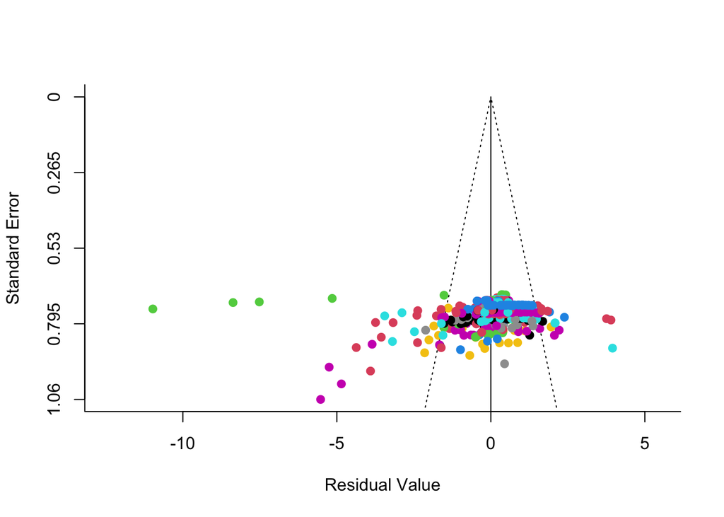

```r
funnel(mod.clinical, legend = F, col=clinical.filtered$PMID,
       back = 'white')
```

```r
tiff(file="results/funnel.colours.clinical.tiff", height=1000, width=1000, pointsize=6, res=300)
funnel(mod.clinical, legend = F, col=clinical.filtered$PMID,
       back = 'white')
dev.off()
```

#### robustness of effect

```r
mod.clinical.bias <- rma.uni(yi, vi,
                             # random = list(~1 | new.idPTSD , ~1 | PMID),
                             mods = ~valence:phase-1,
                             method = "REML",
                             slab = clinical.filtered$reference,
                             data = clinical.filtered)
# summary(mod.preclinical.bias)
```

##### Egger’s regression

```r
regtest(mod.clinical.bias, ret.fit = TRUE) # Egger's regression random effects (mixed not available)
```

```
##
## Regression Test for Funnel Plot Asymmetry
##
## model:     mixed-effects meta-regression model
## predictor: standard error
##
## Mixed-Effects Model (k = 547; tau^2 estimator: REML)
##
## tau^2 (estimated amount of residual heterogeneity):     1.2442 (SE = 0.0828)
## tau (square root of estimated tau^2 value):             1.1154
## I^2 (residual heterogeneity / unaccounted variability): 93.11%
## H^2 (unaccounted variability / sampling variability):   14.52
##
## Test for Residual Heterogeneity:
## QE(df = 541) = 7216.4982, p-val < .0001
##
## Test of Moderators (coefficients 1:6):
## QM(df = 6) = 142.6138, p-val < .0001
##
## Model Results:
##
##                  estimate      se     zval    pval    ci.lb    ci.ub
## valenceF:phaseE    0.3648  0.2519   1.4481  0.1476  -0.1290   0.8586
## valenceF:phaseL    0.6643  0.2377   2.7951  0.0052   0.1985   1.1302   **
## valenceN:phaseL    0.4133  0.2261   1.8284  0.0675  -0.0297   0.8564    .
## valenceE:phaseM    0.1250  0.2597   0.4812  0.6304  -0.3840   0.6340
## valenceN:phaseM    0.4127  0.2061   2.0027  0.0452   0.0088   0.8167    *
## sei               -2.8354  0.5910  -4.7977  <.0001  -3.9937  -1.6771  ***
##
## ---
## Signif. codes:  0 '***' 0.001 '**' 0.01 '*' 0.05 '.' 0.1 ' ' 1
##
## test for funnel plot asymmetry: z = -4.7977, p < .0001
```

##### file drawer analysis (fail and safe)

file drawer analysis is performed within valence x phase subgroups

```r
fsn.table.clincal <- data.frame(matrix(data = NA, nrow = 5, ncol = 4)) #V new

names(fsn.table.clincal)<-c("valence", "phase", "Fail-save N", "Pvalue")

fsn(yi = yi, vi = vi,
    data = clinical.filtered,
    subset = (clinical.filtered$valence == "F" & clinical.filtered$phase == "E"),
    type = "Rosenthal") ->fsnFE.clinical
fsnFE.clinical
```

```
##
## Fail-safe N Calculation Using the Rosenthal Approach
##
## Observed Significance Level: <.0001
## Target Significance Level:   0.05
##
## Fail-safe N: 10303
```

```r
fsn.table.clincal[1,] <- c("F", "E", fsnFE.clinical$fsnum, fsnFE.clinical$pval)
```

```r
fsn(yi = yi, vi = vi,
    data = clinical.filtered,
    subset = (clinical.filtered$valence == "F" & clinical.filtered$phase == "L"),
    type = "Rosenthal") ->fsnFL.clinical
fsnFL.clinical
```

```
##
## Fail-safe N Calculation Using the Rosenthal Approach
##
## Observed Significance Level: <.0001
## Target Significance Level:   0.05
##
## Fail-safe N: 1634
```

```r
fsn.table.clincal[2,] <- c("F", "L", fsnFL.clinical$fsnum, fsnFL.clinical$pval)
```

```r
fsn(yi = yi, vi = vi,
    data = clinical.filtered,
    subset = (clinical.filtered$valence == "N" & clinical.filtered$phase == "L"),
    type = "Rosenthal") ->fsnNL.clinical
fsnNL.clinical
```

```
##
## Fail-safe N Calculation Using the Rosenthal Approach
##
## Observed Significance Level: <.0001
## Target Significance Level:   0.05
##
## Fail-safe N: 7914
```

```r
fsn.table.clincal[3,] <- c("N", "L", fsnNL.clinical$fsnum, fsnNL.clinical$pval)
```

```r
fsn(yi = yi, vi = vi,
    data = clinical.filtered,
    subset = (clinical.filtered$valence == "E" & clinical.filtered$phase == "M"),
    type = "Rosenthal") ->fsnEM.clinical
fsnEM.clinical
```

```
##
## Fail-safe N Calculation Using the Rosenthal Approach
##
## Observed Significance Level: <.0001
## Target Significance Level:   0.05
##
## Fail-safe N: 4467
```

```r
fsn.table.clincal[4,] <- c("E", "M", fsnEM.clinical$fsnum, fsnEM.clinical$pval)
```

```r
fsn(yi = yi, vi = vi,
    data = clinical.filtered,
    subset = (clinical.filtered$valence == "N" & clinical.filtered$phase == "M"),
    type = "Rosenthal") ->fsnNM.clinical
fsnNM.clinical
```

```
##
## Fail-safe N Calculation Using the Rosenthal Approach
##
## Observed Significance Level: <.0001
## Target Significance Level:   0.05
##
## Fail-safe N: 52014
```

```r
fsn.table.clincal[5,] <- c("N", "M", fsnNM.clinical$fsnum, fsnNM.clinical$pval)
```

###### view and save complete table

```r
fsn.table.clincal$Pvalue <- round(as.numeric(fsn.table.clincal$Pvalue),3)
fsn.table.clincal$Pvalue<- ifelse(fsn.table.clincal$Pvalue == 0, "<.001",fsn.table.clincal$Pvalue)

fsn.table.clincal
```

```
##   valence phase Fail-save N Pvalue
## 1       F     E       10303  <.001
## 2       F     L        1634  <.001
## 3       N     L        7914  <.001
## 4       E     M        4467  <.001
## 5       N     M       52014  <.001
```

```r
write.csv2(fsn.table.clincal, "results/phase_valence_PTSD_clinical.FSN.csv")
```

##### trim and fill

only available for model without moderators, since moderation is present.. not valid test for robustness of the effects?

### Sensitivity analysis clinical

#### study quality

```r
mod.clinical.QA <- rma.mv(yi, vi,
                          random = list(~1 | new.idPTSD , ~1 | PMID),
                          # mods = ~valence:phase-1,
                          mods = ~RoB_score,#*valence:phase-1,  # valeria doet ook alleen 'blinding and randomized variable as moderator in model"
                          method = "REML",
                          slab = clinical.filtered$reference,
                          data = clinical.filtered)
summary(mod.clinical.QA)
```

```
##
## Multivariate Meta-Analysis Model (k = 547; method: REML)
##
##     logLik    Deviance         AIC         BIC        AICc
## -2192.7136   4385.4271   4393.4271   4410.6303   4393.5012
##
## Variance Components:
##
##             estim    sqrt  nlvls  fixed      factor
## sigma^2.1  0.0481  0.2194     97     no  new.idPTSD
## sigma^2.2  0.4287  0.6547     92     no        PMID
##
## Test for Residual Heterogeneity:
## QE(df = 545) = 7342.3863, p-val < .0001
##
## Test of Moderators (coefficient 2):
## QM(df = 1) = 0.0616, p-val = 0.8041
##
## Model Results:
##
##            estimate      se     zval    pval    ci.lb    ci.ub
## intrcpt     -0.5725  0.1298  -4.4094  <.0001  -0.8270  -0.3180  ***
## RoB_score    0.0293  0.1180   0.2481  0.8041  -0.2020   0.2605
##
## ---
## Signif. codes:  0 '***' 0.001 '**' 0.01 '*' 0.05 '.' 0.1 ' ' 1
```

#### Influential cases

phase x valence meta-regression without cases that were identified as influential & outlier -> for sensitivity analysis

```r
source("R/influentials_valence_phase.R")
```

```r
clinical.inf<-influentials_valence_phase(clinical.filtered)
```

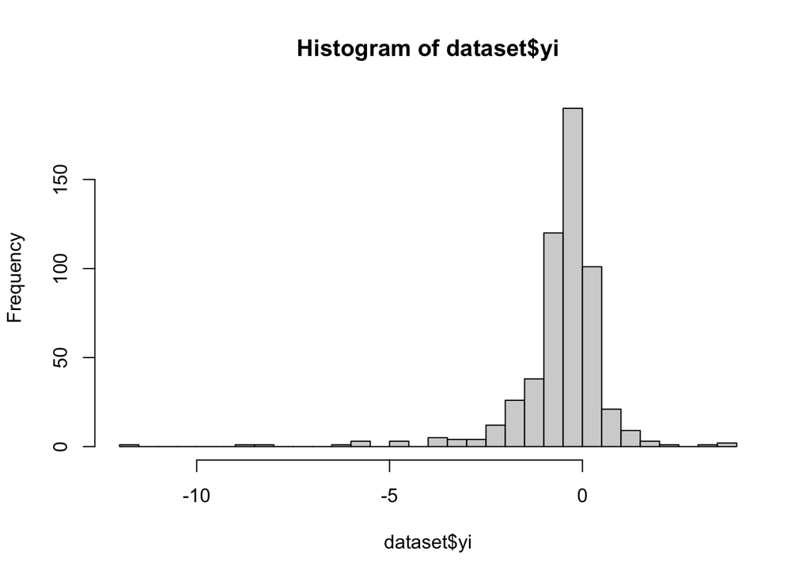

```r
saveRDS(clinical.inf, "processed_data/influentials.clinical.rds")
```

```r
readRDS("processed_data/influentials.clinical.rds")->clinical.inf
```

potential outlier and influential cases

```r
clinical.inf[which(clinical.inf$outInf == 1),] %>% nrow()
```

```
## [1] 17
```

studies with potential outlier and influential cases

```r
clinical.inf[which(clinical.inf$outInf == 1),]%>% distinct(PMID) %>% nrow()
```

```
## [1] 8
```

```r
# # potential outliers
# clinical.inf[which(clinical.inf$potOut == 1),] %>% nrow()
# clinical.inf[which(clinical.inf$potOut == 1),]%>% distinct(PMID) %>% nrow()
```

remove outliers + influential (Viechtbauer & Cheung)

```r
clinical.inf %>%
  filter(outInf != 1) %>%
  droplevels() -> clinical.noinfout
```

model without potential outliers + infuential cases

```r
mod.clinical.noinf <- rma.mv(yi, vi,
                             random = list(~1 | new.idPTSD , ~1 | PMID),
                             mods = ~valence:phase-1,
                             method = "REML",
                             slab = clinical.noinfout$reference,  # from old codes milou (change for author/year)
                             data = clinical.noinfout) # Similar effects with dat2 (trauma learning excluded)
summary(mod.clinical.noinf)
```

```
##
## Multivariate Meta-Analysis Model (k = 530; method: REML)
##
##    logLik   Deviance        AIC        BIC       AICc
## -752.0797  1504.1594  1518.1594  1548.0032  1518.3760
##
## Variance Components:
##
##             estim    sqrt  nlvls  fixed      factor
## sigma^2.1  0.0585  0.2419     97     no  new.idPTSD
## sigma^2.2  0.1753  0.4187     92     no        PMID
##
## Test for Residual Heterogeneity:
## QE(df = 525) = 2293.2192, p-val < .0001
##
## Test of Moderators (coefficients 1:5):
## QM(df = 5) = 121.8527, p-val < .0001
##
## Model Results:
##
##                  estimate      se     zval    pval    ci.lb    ci.ub
## valenceF:phaseE   -0.4066  0.1180  -3.4454  0.0006  -0.6379  -0.1753  ***
## valenceF:phaseL   -0.0990  0.1130  -0.8767  0.3807  -0.3205   0.1224
## valenceN:phaseL   -0.6642  0.0693  -9.5842  <.0001  -0.8001  -0.5284  ***
## valenceE:phaseM   -0.5202  0.0947  -5.4940  <.0001  -0.7057  -0.3346  ***
## valenceN:phaseM   -0.5492  0.0636  -8.6376  <.0001  -0.6738  -0.4246  ***
##
## ---
## Signif. codes:  0 '***' 0.001 '**' 0.01 '*' 0.05 '.' 0.1 ' ' 1
```

save

```r
# create same structure as main analysis: effectsize    se  ci.lb   ci.ub   Zvalue  Pvalue  Pvalue_bonfCorr
  cbind(rownames(mod.clinical.noinf$b),
        round(
                 data.frame(
                 mod.clinical.noinf$b, mod.clinical.noinf$se,
                 mod.clinical.noinf$ci.lb, mod.clinical.noinf$ci.ub,
                 mod.clinical.noinf$zval, mod.clinical.noinf$pval,row.names = NULL),
                 3)
  ) ->sens.infout.clinical.results

colnames(sens.infout.clinical.results)<-c("test","effectsize",  "se",   "ci.lb",    "ci.ub",    "Zvalue",   "Pvalue")

# correct pvalue 0
sens.infout.clinical.results %>% mutate(Pvalue= ifelse(Pvalue == 0, "<.001", Pvalue))->sens.infout.clinical.results2

write.csv2(sens.infout.clinical.results2,"results/sens.clinical.infout.csv")
```

#### comparision types

##### A non-trauma exposed vs PTSD

[A= non-exposed vs trauma-exposed PTSD (human); E=non-exposed vs trauma-exposed PTSD (animal)

```r
# Clinical data
data %>%
  filter(subject.cat =="Human") %>%
  filter(comparison =="A") %>%
  droplevels() ->clinical.filtered.HC.PTSD

clinical.filtered.HC.PTSD %>% group_by(phase, valence) %>%
  summarize(papers=length(unique(PMID)), comparisons=length(each)) %>% data.frame()
```

```
##   phase valence papers comparisons
## 1     E       F      6          41
## 2     L       F     12          43
## 3     L       N     14          32
## 4     M       E      7          21
## 5     M       N     26          99
## 6     M       T      1           1
```

```r
rma.mv(yi, vi,
       random = list(~1 | new.idPTSD , ~1 | PMID),
       mods = ~valence:phase-1,
       method = "REML",
       slab = clinical.filtered.HC.PTSD$reference,
       data = clinical.filtered.HC.PTSD) ->mod.A
summary(mod.A)
```

```
##
## Multivariate Meta-Analysis Model (k = 237; method: REML)
##
##    logLik   Deviance        AIC        BIC       AICc
## -626.3772  1252.7545  1268.7545  1296.2938  1269.4031
##
## Variance Components:
##
##             estim    sqrt  nlvls  fixed      factor
## sigma^2.1  0.0496  0.2227     44     no  new.idPTSD
## sigma^2.2  0.4850  0.6964     39     no        PMID
##
## Test for Residual Heterogeneity:
## QE(df = 231) = 1790.4375, p-val < .0001
##
## Test of Moderators (coefficients 1:6):
## QM(df = 6) = 70.2103, p-val < .0001
##
## Model Results:
##
##                  estimate      se     zval    pval    ci.lb    ci.ub
## valenceF:phaseE   -0.5114  0.2257  -2.2655  0.0235  -0.9539  -0.0690    *
## valenceF:phaseL   -0.3875  0.2192  -1.7674  0.0772  -0.8172   0.0422    .
## valenceN:phaseL   -0.8752  0.1570  -5.5754  <.0001  -1.1828  -0.5675  ***
## valenceE:phaseM   -0.6014  0.1701  -3.5364  0.0004  -0.9347  -0.2681  ***
## valenceN:phaseM   -0.6000  0.1460  -4.1107  <.0001  -0.8861  -0.3139  ***
## valenceT:phaseM    2.6602  0.5931   4.4852  <.0001   1.4977   3.8226  ***
##
## ---
## Signif. codes:  0 '***' 0.001 '**' 0.01 '*' 0.05 '.' 0.1 ' ' 1
```

save

```r
# create same structure as main analysis: effectsize    se  ci.lb   ci.ub   Zvalue  Pvalue  Pvalue_bonfCorr
  cbind(rownames(mod.A$b),
        round(
                 data.frame(
                 mod.A$b, mod.A$se,
                 mod.A$ci.lb, mod.A$ci.ub,
                 mod.A$zval, mod.A$pval,row.names = NULL),
                 3)
  ) ->mod.A.results

colnames(mod.A.results)<-c("test","effectsize", "se",   "ci.lb",    "ci.ub",    "Zvalue",   "Pvalue")

# correct pvalue 0
mod.A.results %>% mutate(Pvalue= ifelse(Pvalue == 0, "<.001", Pvalue))->mod.A.results2

write.csv2(mod.A.results2,"results/sens.mod.A.csv")
```

##### B non-trauma exposed vs trauma-exposed HC

B=non-exposed vs trauma exposed no PTSD (human); D=non-exposed vs trauma-exposed (no PTSD checked) (animal)

```r
# Clinical data
data %>%
  filter(subject.cat =="Human") %>%
  filter(comparison =="B") %>%
  droplevels() ->clinical.filtered.HC.TC

clinical.filtered.HC.TC %>% group_by(phase, valence) %>%
  summarize(papers=length(unique(PMID)), comparisons=length(each)) %>% data.frame()
```

```
##   phase valence papers comparisons
## 1     L       N      1           1
## 2     M       N      2           4
```

> Only one level of valence (Neutral) is available for comparision B, therefore valence excluded from this model

NOTE, model below contains only neutral valence

```r
rma.mv(yi, vi,
       random = list(~1 | new.idPTSD , ~1 | PMID),
       mods = ~phase-1,
       method = "REML",
       slab = clinical.filtered.HC.TC$reference,
       data = clinical.filtered.HC.TC) ->mod.B

summary(mod.B)
```

```
##
## Multivariate Meta-Analysis Model (k = 5; method: REML)
##
##   logLik  Deviance       AIC       BIC      AICc
##   0.7758   -1.5515    6.4485    2.8429   46.4485
##
## Variance Components:
##
##             estim    sqrt  nlvls  fixed      factor
## sigma^2.1  0.0000  0.0000      2     no  new.idPTSD
## sigma^2.2  0.0000  0.0000      2     no        PMID
##
## Test for Residual Heterogeneity:
## QE(df = 3) = 0.3446, p-val = 0.9514
##
## Test of Moderators (coefficients 1:2):
## QM(df = 2) = 4.1541, p-val = 0.1253
##
## Model Results:
##
##         estimate      se     zval    pval    ci.lb    ci.ub
## phaseL   -0.1263  0.4382  -0.2882  0.7732  -0.9851   0.7326
## phaseM   -0.2746  0.1361  -2.0177  0.0436  -0.5413  -0.0079  *
##
## ---
## Signif. codes:  0 '***' 0.001 '**' 0.01 '*' 0.05 '.' 0.1 ' ' 1
```

save

```r
# create same structure as main analysis: effectsize    se  ci.lb   ci.ub   Zvalue  Pvalue  Pvalue_bonfCorr
  cbind(rownames(mod.B$b),
        round(
                 data.frame(
                 mod.B$b, mod.B$se,
                 mod.B$ci.lb, mod.B$ci.ub,
                 mod.B$zval, mod.B$pval,row.names = NULL),
                 3)
  ) ->mod.B.results

colnames(mod.B.results)<-c("test","effectsize", "se",   "ci.lb",    "ci.ub",    "Zvalue",   "Pvalue")

# correct pvalue 0
mod.B.results %>% mutate(Pvalue= ifelse(Pvalue == 0, "<.001", Pvalue))->mod.B.results2

write.csv2(mod.B.results2,"results/sens.mod.B.csv")
```

##### C trauma exposed vs PTSD

C=trauma-exposed (noPTSD) vs trauma-exposed PTSD (human); F=trauma-exposed (no ptsd) vs trauma-exposed PTSD (animal)]

```r
# Clinical data
data %>%
  filter(subject.cat =="Human") %>%
  filter(comparison =="C") %>%
  droplevels() ->clinical.filtered.TC.PTSD

clinical.filtered.TC.PTSD %>% group_by(phase, valence) %>%
  summarize(papers=length(unique(PMID)), comparisons=length(each)) %>% data.frame()
```

```
##   phase valence papers comparisons
## 1     E       F     10          40
## 2     L       F     13          39
## 3     L       N     29          63
## 4     L       T      1           1
## 5     M       E     10          28
## 6     M       F      1           2
## 7     M       N     44         141
## 8     M       T      2           2
```

```r
rma.mv(yi, vi,
       random = list(~1 | new.idPTSD , ~1 | PMID),
       mods = ~valence:phase-1,
       method = "REML",
       slab = clinical.filtered.TC.PTSD$reference,
       data = clinical.filtered.TC.PTSD) -> mod.C
summary(mod.C)
```

```
##
## Multivariate Meta-Analysis Model (k = 316; method: REML)
##
##     logLik    Deviance         AIC         BIC        AICc
## -1445.8571   2891.7141   2911.7141   2949.0151   2912.4549
##
## Variance Components:
##
##             estim    sqrt  nlvls  fixed      factor
## sigma^2.1  0.2109  0.4593     64     no  new.idPTSD
## sigma^2.2  0.2109  0.4593     64     no        PMID
##
## Test for Residual Heterogeneity:
## QE(df = 308) = 5061.7837, p-val < .0001
##
## Test of Moderators (coefficients 1:8):
## QM(df = 8) = 218.0011, p-val < .0001
##
## Model Results:
##
##                  estimate      se     zval    pval    ci.lb    ci.ub
## valenceF:phaseE   -1.0217  0.1876  -5.4460  <.0001  -1.3894  -0.6540  ***
## valenceF:phaseL    0.0977  0.1844   0.5299  0.5962  -0.2637   0.4591
## valenceN:phaseL   -0.5445  0.1040  -5.2345  <.0001  -0.7484  -0.3406  ***
## valenceT:phaseL   -1.1607  0.2980  -3.8953  <.0001  -1.7448  -0.5767  ***
## valenceE:phaseM   -0.8540  0.1595  -5.3542  <.0001  -1.1666  -0.5414  ***
## valenceF:phaseM    0.5606  0.3804   1.4737  0.1406  -0.1850   1.3062
## valenceN:phaseM   -0.4756  0.0991  -4.8000  <.0001  -0.6698  -0.2814  ***
## valenceT:phaseM   -0.1013  0.2851  -0.3555  0.7222  -0.6600   0.4574
##
## ---
## Signif. codes:  0 '***' 0.001 '**' 0.01 '*' 0.05 '.' 0.1 ' ' 1
```

save

```r
# create same structure as main analysis: effectsize    se  ci.lb   ci.ub   Zvalue  Pvalue  Pvalue_bonfCorr
  cbind(rownames(mod.C$b),
        round(
                 data.frame(
                 mod.C$b, mod.C$se,
                 mod.C$ci.lb, mod.C$ci.ub,
                 mod.C$zval, mod.C$pval,row.names = NULL),
                 3)
  ) ->mod.C.results

colnames(mod.C.results)<-c("test","effectsize", "se",   "ci.lb",    "ci.ub",    "Zvalue",   "Pvalue")

# correct pvalue 0
mod.C.results %>% mutate(Pvalue= ifelse(Pvalue == 0, "<.001", Pvalue))->mod.C.results2

write.csv2(mod.C.results2,"results/sens.mod.C.csv")
```

## Research Question 2: Learning and Memory of emotional and non-emotional information in animal models of PTSD

### Model

```r
mod.preclinical <- rma.mv(yi, vi,
                          random = list(~1 | new.idPTSD , ~1 | PMID),
                          mods = ~valence:phase-1,
                          method = "REML",
                          slab = preclinical$reference,
                          data = preclinical)
summary(mod.preclinical)
```

```
##
## Multivariate Meta-Analysis Model (k = 1089; method: REML)
##
##     logLik    Deviance         AIC         BIC        AICc
## -2373.7106   4747.4212   4765.4212   4810.3003   4765.5891
##
## Variance Components:
##
##             estim    sqrt  nlvls  fixed      factor
## sigma^2.1  0.2669  0.5166    309     no  new.idPTSD
## sigma^2.2  1.5472  1.2439    182     no        PMID
##
## Test for Residual Heterogeneity:
## QE(df = 1082) = 5762.9431, p-val < .0001
##
## Test of Moderators (coefficients 1:7):
## QM(df = 7) = 1445.3712, p-val < .0001
##
## Model Results:
##
##                  estimate      se     zval    pval    ci.lb    ci.ub
## valenceF:phaseE   -0.7406  0.1369  -5.4105  <.0001  -1.0089  -0.4723  ***
## valenceT:phaseE   -2.1896  0.2297  -9.5316  <.0001  -2.6399  -1.7394  ***
## valenceF:phaseL    0.4347  0.1455   2.9867  0.0028   0.1494   0.7200   **
## valenceN:phaseL   -1.3036  0.1554  -8.3870  <.0001  -1.6083  -0.9990  ***
## valenceF:phaseM    0.8118  0.1362   5.9619  <.0001   0.5449   1.0787  ***
## valenceN:phaseM   -1.2908  0.1515  -8.5185  <.0001  -1.5878  -0.9938  ***
## valenceT:phaseM    1.8770  0.1384  13.5630  <.0001   1.6057   2.1482  ***
##
## ---
## Signif. codes:  0 '***' 0.001 '**' 0.01 '*' 0.05 '.' 0.1 ' ' 1
```

### add contrasts

```r
TRACE_preclinical_valence_phase <- function(model){

  fearExtinction <- anova(model, L = c(1,0, 0, 0,0,0,0))
  traumaExtinction <-anova(model, L = c(0,1, 0, 0,0,0,0))

  fearLearning <- anova(model, L = c(0,0,1, 0,0,0,0))
  neutralLearning <- anova(model, L = c(0,0,0, 1, 0,0,0))
  # emotionalMemory <- anova(model, L = c(0,0, 0, 1,0,0,0))
  fearMemory <- anova(model, L = c(0,0, 0,0,1,0,0))
  neutralMemory <- anova(model, L = c(0,0, 0, 0, 0,1,0))
  traumaMemory <- anova(model, L = c(0,0, 0, 0, 0,0,1))

    valence.learning <-anova(model, L = c(0,0,1,-1,
                                        0,0,0)) # neutral (-) vs fear learning

  valence.memory.NF <- anova(model, L = c(0,0,0,0, # neutral (-) vs fear memory
                                          1,-1, 0))

  valence.memory.NT <- anova(model, L = c(0,0,0,0, # neutral (-) vs trauma memory
                                          0,-1, 1))

  valence.memory.FT <- anova(model, L = c(0,0,0,0, # fear (-) vs trauma memory
                                          -1,0, 1))

  valence.extinction <- anova(model, L= c(-1, 1,0,0,
                                          0,0,0)) # fear (-) vs trauma extinction


  ##Summary results organized in table
  resultMain <- data.frame(matrix(data = NA, nrow = 12, ncol = 8)) #V new

  # colnames(resultMain) <- c("test",
  #                           "effectsize", "se", "ci.lb", "ci.ub",
  #                           "Zvalue",
  #                           "Pvalue", "Pvalue_bonfCorr")
    colnames(resultMain) <- c("test", "effectsize", "se", "ci.lb", "ci.ub", "Zvalue", "Pvalue", "Pvalue_bonfCorr")

  resultMain[,1] <- c(

    "neutral Learning", "neutral Memory",
    "fear Learning", "fear Memory", "fear Extinction",
    "trauma Memory","trauma Extinction",

        "valence.learning: neutral vs fear (learning)",
    "valence.memory NF: neutral vs fear (memory)", "valence.memory NT: neutral vs trauma (memory)",  "valence.memory FT: fear vs trauma (memory)",
    "valence.extinction: fear vs trauma (extinction)")

  resultMain[,2] <- round(c(

    neutralLearning$Lb, neutralMemory$Lb,
    fearLearning$Lb, fearMemory$Lb,  fearExtinction$Lb,
    traumaMemory$Lb, traumaExtinction$Lb,
        valence.learning$Lb,
    valence.memory.NF$Lb, valence.memory.NT$Lb, valence.memory.FT$Lb,
    valence.extinction$Lb

  ), digits = 4) #effect size

  resultMain[,3] <- round(c(

    neutralLearning$se, neutralMemory$se,
    fearLearning$se, fearMemory$se,  fearExtinction$se,
    traumaMemory$se, traumaExtinction$se,
        valence.learning$se,
    valence.memory.NF$se, valence.memory.NT$se, valence.memory.FT$se,
    valence.extinction$se
  ), digits = 4) #se

    resultMain[,4] <- round(resultMain[,2] - (resultMain[,3] * 1.96), digits = 4) #CI lower
  resultMain[,5] <- round(resultMain[,2] + (resultMain[,3] * 1.96), digits = 4) #CI upper

  resultMain[,6] <- round(c(

    neutralLearning$zval, neutralMemory$zval,
    fearLearning$zval, fearMemory$zval,  fearExtinction$zval,
    traumaMemory$zval, traumaExtinction$zval,

        valence.learning$zval,
    valence.memory.NF$zval, valence.memory.NT$zval, valence.memory.FT$zval,
    valence.extinction$zval
  ), digits = 4)  #zvalues

  resultMain[,7] <- round(c(

    neutralLearning$pval, neutralMemory$pval,
    fearLearning$pval, fearMemory$pval,  fearExtinction$pval,
    traumaMemory$pval, traumaExtinction$pval,

        valence.learning$pval,
    valence.memory.NF$pval, valence.memory.NT$pval, valence.memory.FT$pval,
    valence.extinction$pval
  ), digits = 4)  #pvalues


  resultMain[,8] <- round(p.adjust(resultMain[,7], method = "bonferroni", n = 12),
                          digits = 4) #pvalue bonf correction

  return(resultMain)

}

TRACE_preclinical_valence_phase(mod.preclinical)->preclinical.results
```

### create plot

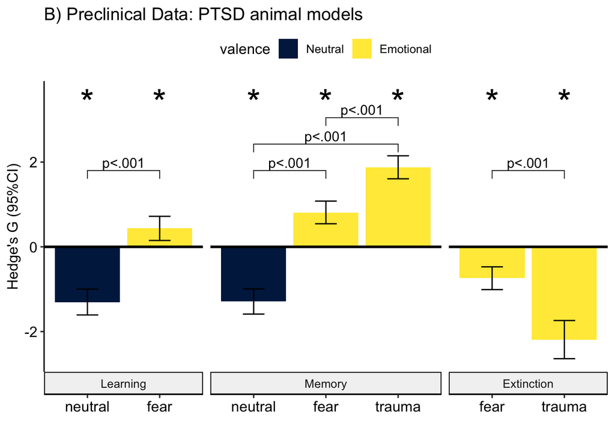

```r
preclinical.results %>%
  filter(test %in% c("neutral Learning", "neutral Memory",
                     "fear Learning", "fear Memory", "fear Extinction",
                     "trauma Memory","trauma Extinction"
  )) %>%
  mutate(
    valence = ifelse(test %in% c("neutral Learning", "neutral Memory"), "Neutral", "Emotional"),
    phase = case_when(
      grepl("Learning",test) ~ "Learning",
      grepl("Memory",test) ~ "Memory",
      grepl("Extinction",test) ~ "Extinction"
    ),
    # signal sig. categories. Add index for p-values smaller than 0.05
    sig =ifelse(Pvalue_bonfCorr<0.05, 1, 0),
    valence= factor(valence, levels =c("Neutral", "Emotional")),
    test = factor(test, levels = c("neutral Learning", "fear Learning", "neutral Memory", "fear Memory", "trauma Memory", "fear Extinction", "trauma Extinction")#,
                  # labels = c("neutral", "fear", "neutral", "emotional", "fear")
    )
  ) ->preclinical_plot_data_coded


# https://www.datanovia.com/en/blog/ggpubr-how-to-add-p-values-generated-elsewhere-to-a-ggplot/
preclinical.results %>%
  select(test,p=Pvalue_bonfCorr) %>%
  filter(grepl("valence",test,fixed = T)) %>%
  mutate(
    group1 = case_when(
      grepl("valence.learning",test) ~ "neutral Learning",
      grepl("valence.memory NF",test) ~ "neutral Memory",
      grepl("valence.memory NT",test) ~ "neutral Memory",
      grepl("valence.memory FT",test) ~ "fear Memory",
      grepl("valence.extinction",test) ~ "fear Extinction"
    ),
    group2 = case_when(
      grepl("valence.learning",test) ~ "fear Learning",
      grepl("valence.memory NF",test) ~ "fear Memory",
      grepl("valence.memory NT",test) ~ "trauma Memory",
      grepl("valence.memory FT",test) ~ "trauma Memory",
      grepl("valence.extinction",test) ~ "trauma Extinction"
    ),
    phase = case_when(
      grepl("learning",test) ~ "Learning",
      grepl("memory",test) ~ "Memory",
      grepl("extinction",test) ~ "Extinction"
    ),
    p.adj = ifelse(p == 0, yes = "p<.001", no = paste0("p=",round(p,3)))
  ) %>% group_by(phase)-> preclinical.posthoc.valence


PLOT.preclinical <-
  ggplot(preclinical_plot_data_coded,
         aes(x = test, y = effectsize, fill=valence)) +
  labs(
    title = "B) Preclinical Data: PTSD animal models",
    # subtitle = "PTSD animal models",
    y="Hedge's G (95%CI)", # could also be "Standardized mean difference"
    x="") +
  facet_grid (.~ factor(phase, levels =c("Learning", "Memory", "Extinction")),  # width scaled (better for extinction)
              scales = "free_x", space = "free_x", switch = "x" # labels onder
              # je kan de andere factor levels nog toevoegen en dan hier drop =F, bv voor het vergelijkbaar maken met dieren?
  ) +
  # theme_linedraw() +
    theme_pubr(base_size = 12)+
  # theme(plot.title = element_text(hjust = 0.5)) +
  # theme(plot.subtitle = element_text(hjust = 0.5, face="italic")) +
  # scale_fill_manual(
  #   values= c( "Neutral" = "steelblue2", # Colours: http://sape.inf.usi.ch/quick-reference/ggplot2/colour
  #              "Emotional" = "tomato2")) +

     scale_fill_viridis(discrete = TRUE, #begin = 0.1, end = 0.9 ,
                        option = "cividis") +

  geom_bar(stat = "identity")+
  geom_hline(yintercept = 0, size = 1) +
  geom_errorbar(aes(ymin = ci.lb,
                    ymax = ci.ub),
                width = .3) +
  # theme(axis.text.x = element_text(angle = 45, vjust = 1, hjust=1)) +

  # sig marks
  geom_point(data = preclinical_plot_data_coded[preclinical_plot_data_coded$sig ==1, ],aes(x=test, y=3.6), shape = "*", size=10, show.legend = FALSE) +  # to make position dynamic use: y=ci.ub+1.5

  ggpubr::stat_pvalue_manual(data.frame(preclinical.posthoc.valence), inherit.aes=F,
                             y.position = 1.8, step.increase = 0.1,
                             step.group.by ="phase",
                             # label = "p = {round(p,3)}", # this works
                             label = "p.adj",
                             size=4) +

  scale_x_discrete(labels=c("neutral Learning" = "neutral",
                            "fear Learning" = "fear",
                            "neutral Memory" = "neutral",
                            "fear Memory" = "fear",
                            "trauma Memory" = "trauma",
                            "fear Extinction" = "fear",
                            "trauma Extinction"= "trauma"))

PLOT.preclinical
```